# RProject: Transcriptional and proteomic insights into the host response in fatal COVID-19 cases

**RProject**: Transcriptional and proteomic insights into the host response in fatal COVID-19 cases Bioinformatics I Ilaria Coratella

## Introduction

[figure not shown]

I chose this article, which analyzes pathways related to neutrophil activation and pulmonary fibrosis among the major up-regulated transcriptional signatures in lung tissue obtained from patients who died of COVID-19 in Wuhan, China. Examination of the colonic transcriptome of these patients suggested that SARS-CoV-2 impacted host responses even at a site with no obvious pathogenesis.

## Covid 19

SARS-CoV-2, the etiologic agent for coronavirus disease 2019 (COVID-19), emerged in Wuhan, China, in late December 2019. Since then, more than 29.5 million people have been infected worldwide, with over 933,000 deaths as of September 15, 2020. Although research into the clinical and scientific features of SARS-CoV-2 pathogenesis has progressed at a dizzying pace, pathogenesis of COVID-19 is still incompletely understood.

## What is the aim of this project?

The aim of this presentation is to show the results of two differential expression analysis, hence to find DEGs in lung and colon tissues of diseased patients. I preferred to perform two symultaneous analysis for the two tissues in order to obtain a more precise result.

## Filtering of the original dataset

Firstly, I have filtered my original experimental design dataset for tissue, and I did it both for lung and colon.

```r
setwd("C:/Users/Ilaria/Desktop/UNI/not_passed/BI1/ProjectR")
library(readxl)
library(writexl)

df <- read_excel("E-ENAD-46-experiment-design - Copiaexcel.xlsx")
df_lung <- df[df$`Sample Characteristic[organism part]` == 'lung', ]
write_xlsx(df_lung, "new_experiment_design_lung_R.xlsx")

df_colon <- df[df$`Sample Characteristic[organism part]` == 'colon', ]
write_xlsx(df_colon, "new_experiment_design_colon_R.xlsx")
```

## Filtered dataset for lung

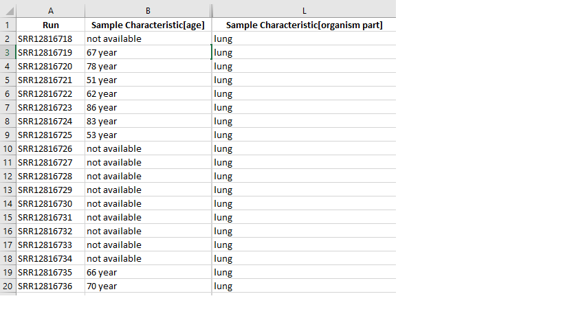

## Filtered dataset for colon

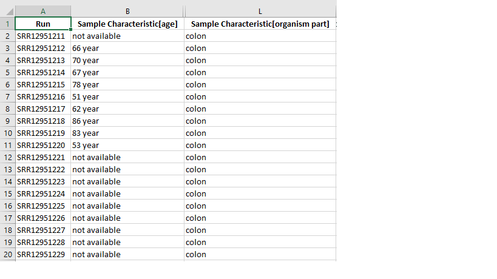

## Filtering of the genes

Once I have separated the samples on the basis of the tissue type, I divided the counts of the genes. This filtering operation has been carried out on the basis of the names of the samples previously divided:

```r
lung_design <- readxl::read_excel("new_experiment_design_lung_R.xlsx")
colon_design <- readxl::read_excel("new_experiment_design_colon_R.xlsx")

lung_sample <- lung_design$Run
colon_sample <- colon_design$Run


count <- readxl::read_excel("E-ENAD-46-raw-counts.xlsx")

lung_counts <- count[,c("Gene ID","Gene Name",lung_sample)]
colon_counts <- count[,c("Gene ID","Gene Name",colon_sample)]

write.table(lung_counts, file = "lung_counts.tsv", quote = F, row.names = F, sep = "\t")
write.table(colon_counts,file = "colon_counts.tsv", quote = F, row.names = F, sep = "\t")

write.table(lung_design, file = "design_lung.tsv", quote = F, row.names = F, sep = "\t")
write.table(colon_design, file = "design_colon.tsv", quote = F, row.names = F, sep = "\t")
```

# Differential expression analysis :

## Importing data as matrices

### I obtained a total of 19 samples, 9 diseased and 10 healthy.

First of all I have uploaded the data of the study, both the study design and the gene counts. I did it both for LUNG and COLON:

**LUNG**

```r
coldata <- read.delim('design_lung.tsv', header = TRUE, row.names = 1)
#export as a matrix: it creates a matrix with the data of the experiment design file.

rowcounts <- read.delim('lung_counts.tsv', header = TRUE, row.names = 1)
#export as a matrix: it creates a matrix with the data of the raw counts file.
```

**COLON**

```r
coldata1 <- read.delim('design_colon.tsv', header = TRUE, row.names = 1)
#export as a matrix: it creates a matrix with the data of the experiment design file.

rowcounts1 <- read.delim('colon_counts.tsv', header = TRUE, row.names = 1)
#export as a matrix: it creates a matrix with the data of the raw counts file.
```

## Removing the ‘extra’ column

Since I noticed that there were two columns to identify the genes, i removed one. In fact, just one column is necessary to perform the Differential Expression Analysis. This is the code to remove the column Gene.Name:

**LUNG**

```r
countData <- as.matrix(subset(rowcounts, select = c(-Gene.Name)))
```

**COLON**

```r
countData1 <- as.matrix(subset(rowcounts1, select = c(-Gene.Name)))
```

## Specify the Sample Type

This function is used to specify to the program in which column of the coldata (experiment design file) it is indicated whether the samples are disease or control.

**LUNG**

```r
designFormula <- "~ Sample.Characteristic.disease."
```

**COLON**

```r
designFormula <- "~ Sample.Characteristic.disease."
```

## RNAseq analysis

**LUNG**

```r
dds <- DESeqDataSetFromMatrix(countData = countData,
                              colData = coldata,
                              design = as.formula(designFormula))
print(dds)
```

```
## class: DESeqDataSet
## dim: 58735 19
## metadata(1): version
## assays(1): counts
## rownames(58735): ENSG00000000003 ENSG00000000005 ... ENSG00000285993
##   ENSG00000285994
## rowData names(0):
## colnames(19): SRR12816718 SRR12816719 ... SRR12816735 SRR12816736
## colData names(21): Sample.Characteristic.age.
##   Sample.Characteristic.Ontology.Term.age. ...
##   Factor.Value.Ontology.Term.organism.part. Analysed
```

**COLON**

```r
dds1 <- DESeqDataSetFromMatrix(countData = countData1,
                              colData = coldata1,
                              design = as.formula(designFormula))
print(dds1)
```

```
## class: DESeqDataSet
## dim: 58735 19
## metadata(1): version
## assays(1): counts
## rownames(58735): ENSG00000000003 ENSG00000000005 ... ENSG00000285993
##   ENSG00000285994
## rowData names(0):
## colnames(19): SRR12951211 SRR12951212 ... SRR12951228 SRR12951229
## colData names(21): Sample.Characteristic.age.
##   Sample.Characteristic.Ontology.Term.age. ...
##   Factor.Value.Ontology.Term.organism.part. Analysed
```

## RNAseq analysis

In order to obtain a more precise result in the end, I decide to filter the genes, keeping only the ones which are expressed more than once. This function saves the genes with 0 expression in all the samples as FALSE, and all the others as TRUE:

**LUNG**

```r
expressed <-rowSums(counts(dds)) > 1
table(expressed)
```

```
## expressed
## FALSE  TRUE
## 17286 41449
```

**COLON**

```r
expressed1 <-rowSums(counts(dds1)) > 1
table(expressed1)
```

```
## expressed1
## FALSE  TRUE
## 16368 42367
```

## RNAseq analysis

Then, I removed my FALSE values from my dds, so that now it will contain only the genes that i have selected.To be more precise.

```r
dds <- dds[expressed, ]
print(dds)
```

```
## class: DESeqDataSet
## dim: 41449 19
## metadata(1): version
## assays(1): counts
## rownames(41449): ENSG00000000003 ENSG00000000005 ... ENSG00000285993
##   ENSG00000285994
## rowData names(0):
## colnames(19): SRR12816718 SRR12816719 ... SRR12816735 SRR12816736
## colData names(21): Sample.Characteristic.age.
##   Sample.Characteristic.Ontology.Term.age. ...
##   Factor.Value.Ontology.Term.organism.part. Analysed
```

```r
dds1 <- dds1[expressed1, ]
print(dds1)
```

```
## class: DESeqDataSet
## dim: 42367 19
## metadata(1): version
## assays(1): counts
## rownames(42367): ENSG00000000003 ENSG00000000005 ... ENSG00000285993
##   ENSG00000285994
## rowData names(0):
## colnames(19): SRR12951211 SRR12951212 ... SRR12951228 SRR12951229
## colData names(21): Sample.Characteristic.age.
##   Sample.Characteristic.Ontology.Term.age. ...
##   Factor.Value.Ontology.Term.organism.part. Analysed
```

## RNAseq analysis

Afterward, I continued with the pipeline by applying DESeq(), which performs count normalization and estimates dispersion values:

**LUNG**

```r
dds <- DESeq(dds)
```

**COLON**

```r
dds1 <- DESeq(dds1)
```

It carries out the analysis, and then overwrites the results in dds.

## RNAseq analysis

Then, I proceeded to create a PCA plot by utilizing the vst() function for normalization. I saved it into another object, called rld.

**LUNG**

```r
rld <- vst(dds)
```

**COLON**

```r
rld1 <- vst(dds1)
```

## RNAseq analysis

Then i can obtain a PCA plot the normalized values I obtain thanks to the previous lines of code

**LUNG**

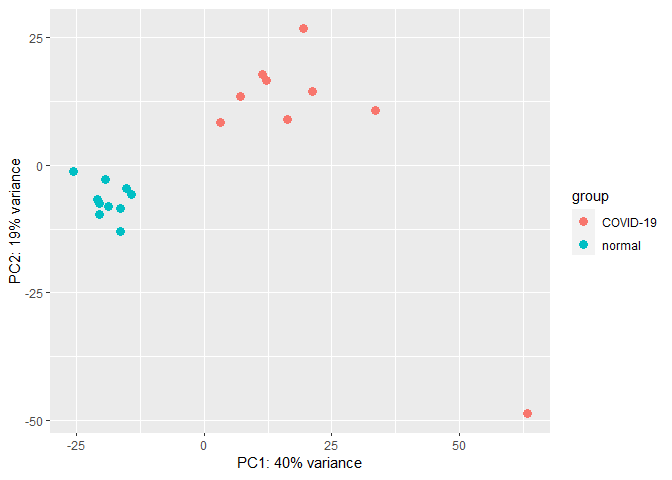

```r
DESeq2::plotPCA(rld, intgroup = 'Sample.Characteristic.disease.')
```

As it is possible to observe, almost all of the samples seem to be correctly classified, with the exception of one sample classified as COVID-19 patient. It may be the result of an error, since it shows a considerable high variance with respect to the other samples.

**COLON**

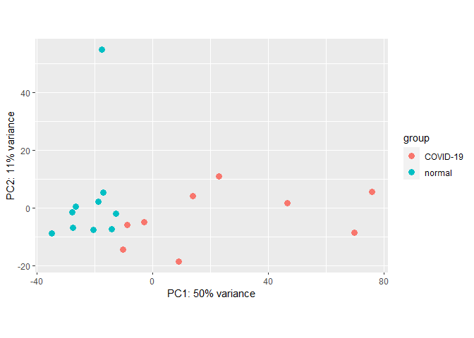

```r
DESeq2::plotPCA(rld1, intgroup = 'Sample.Characteristic.disease.')
```

This PCA plot is messier than the previous one. We can observe a certain kind of separation between the two categories of genes, but the variance is high and COVID-19 and normal samples are close the one with the other. It is probable that, affecting COVID-19 mainly lungs, a difference in gene expression can be easily detect in lungs, but less easily in colon. However, it is interesting that a slight difference in gene expression does still exists, and this is one of the main points of the paper.

## RNAseq analysis

to create an object which describes how different are couples of samples. It is important to build the heatmap of sample sample distance:

**LUNG**

```r
SampleDists <- dist(t(assay(rld)))
SampleDistMatrix <- as.matrix(SampleDists)
```

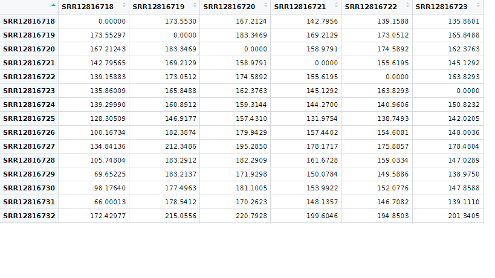

**COLON**

```r
SampleDists1 <- dist(t(assay(rld1)))
SampleDistMatrix1 <- as.matrix(SampleDists1)
```

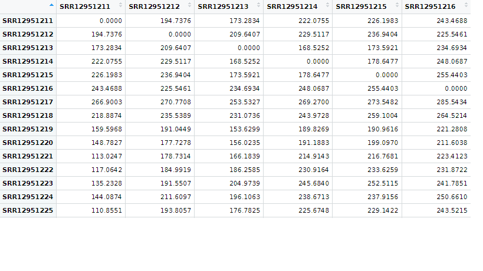

## RNAseq analysis Now I can plot my heatmap:

**LUNG**

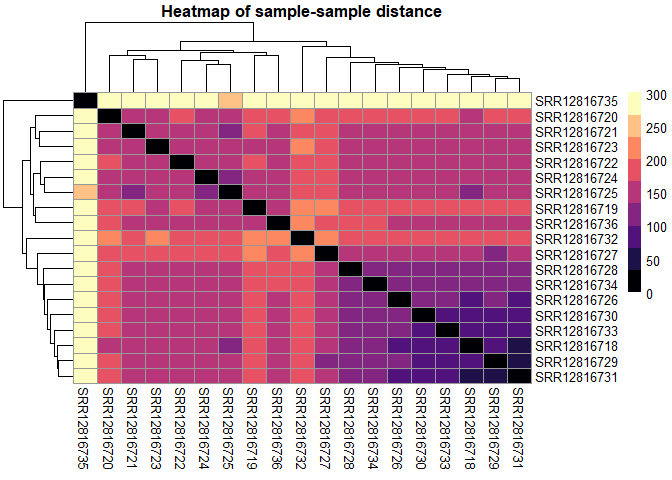

```r
library(viridis)
pheatmap(SampleDistMatrix,
         main = "Heatmap of sample-sample distance",
         clustering_distance_rows = SampleDists,
         clustering_distance_cols = SampleDists,
         col = magma(9))
```

However, we can easily observe a sample, SRR12816735, which is dissimilar to every other sample, and it may be the same we observed before in the PCA plot. Since it is highly possible that it is misclassified, I prefer proceeding removing it.

```r
coldata <- coldata[-18, ]
rowcounts <- rowcounts[, -19]
```

## RNAseq analysis

Now I obtained the same graphs, but without SRR12816735:

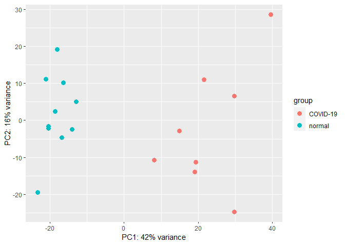

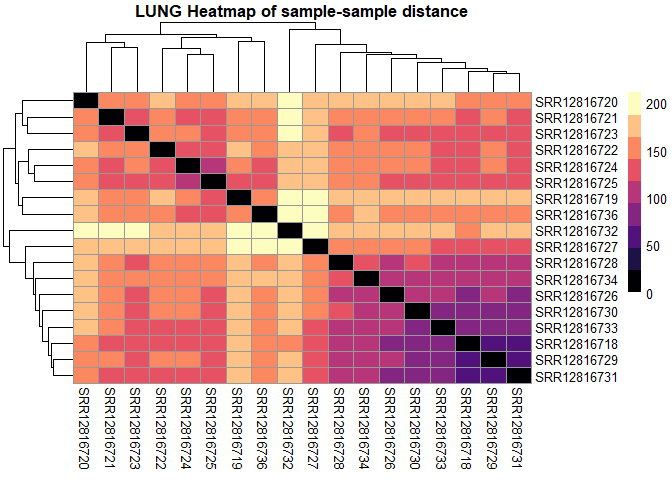

We can observe a more homogeneous PCA and heatmap.

**COLON**

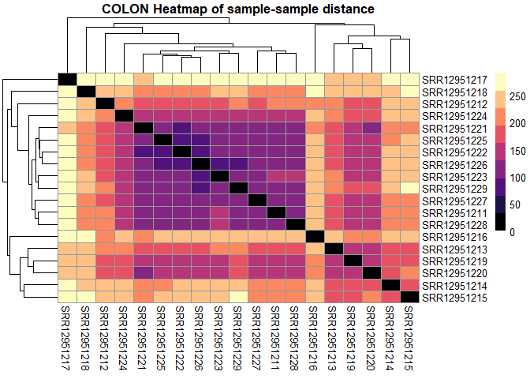

```r
library(viridis)
pheatmap(SampleDistMatrix1,
         main = "COLON Heatmap of sample-sample distance",
         clustering_distance_rows = SampleDists1,
         clustering_distance_cols = SampleDists1,
         col = magma(9))
```

The heatmap of the colon does not show very clean results.

## RNAseq analysis

Than I performed the comparison between the two groups. I specified the coloumn of sampledata (experimental design) that has the group classification: COVID-19 vs normal.

**LUNG** 3447 genes are over overexpressed in dds while 4556 underexpressed.

```r
res <- results(dds, contrast = c("Sample.Characteristic.disease.", 'COVID-19', 'normal'))
summary(res)
```

```
##
## out of 41140 with nonzero total read count
## adjusted p-value < 0.1
## LFC > 0 (up)       : 3447, 8.4%
## LFC < 0 (down)     : 4556, 11%
## outliers [1]       : 0, 0%
## low counts [2]     : 11394, 28%
## (mean count < 1)
## [1] see 'cooksCutoff' argument of ?results
## [2] see 'independentFiltering' argument of ?results
```

```r
res1 <- results(dds1, contrast = c("Sample.Characteristic.disease.", 'COVID-19', 'normal'))
summary(res1)
```

```
##
## out of 42283 with nonzero total read count
## adjusted p-value < 0.1
## LFC > 0 (up)       : 2805, 6.6%
## LFC < 0 (down)     : 7525, 18%
## outliers [1]       : 0, 0%
## low counts [2]     : 9921, 23%
## (mean count < 1)
## [1] see 'cooksCutoff' argument of ?results
## [2] see 'independentFiltering' argument of ?results
```

## VOLCANO PLOT

This is my volcano plot:

**LUNG**

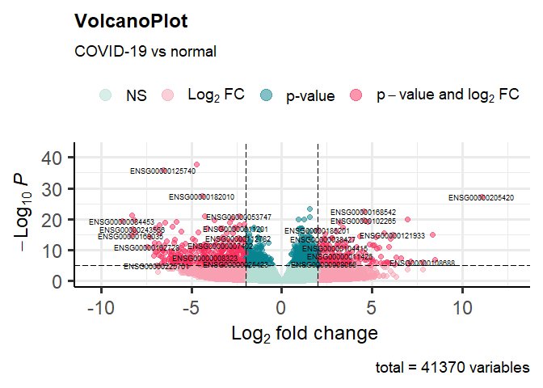

```r
EnhancedVolcano(
  as.data.frame(res),
  labSize = 2.5,
  title = "VolcanoPlot",
  subtitle = "COVID-19 vs normal",
  lab = rownames(res),
  FCcutoff = 2,
  x = 'log2FoldChange',
  y = 'pvalue',
  col = c("#b4ddd4", "#f8a0b1", "#088490", "#f92e5d")
)
```

**COLON**

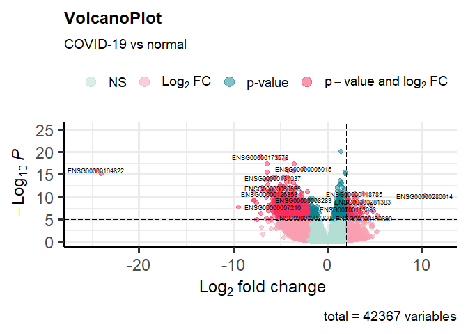

## MAPLOT

This is my MaPlot plot:

**LUNG**

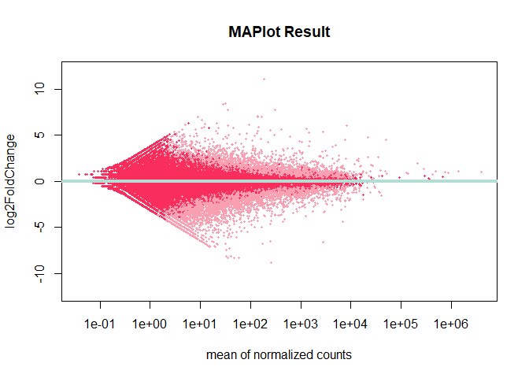

```r
DESeq2::plotMA(object = res,
               main ='MAPlot Result',
               colSig = "#f8a0b1",
               colNonSig = "#f92e5d",
               colLine = "#b4ddd4",
               xlab="mean of normalized counts",
               ylab="log2FoldChange",
               ylim = c(-12, 12))
```

**COLON**

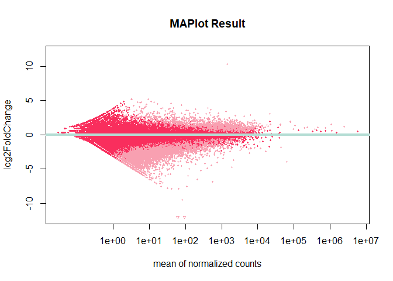

## Comparison with Expression Atlas results: DOWN-regulated **LUNG** genes

C2orf91

As it is observable, we can see a log2foldchange of -8.27, while in the result of the experiment in Expression Atlas it is -7.1

```r
res['ENSG00000205086',]
```

```
## log2 fold change (MLE): Sample.Characteristic.disease. COVID-19 vs normal
## Wald test p-value: Sample.Characteristic.disease. COVID-19 vs normal
## DataFrame with 1 row and 6 columns
##                  baseMean log2FoldChange     lfcSE      stat      pvalue
##                 <numeric>      <numeric> <numeric> <numeric>   <numeric>
## ENSG00000205086   58.5817       -8.27146  0.857919  -9.64131 5.35011e-22
##                        padj
##                   <numeric>
## ENSG00000205086 2.29107e-18
```

UPK3B

As it is observable, we can see a log2foldchange of -8.25, while in the result of the experiment in Expression Atlas it is -6.8

```r
res['ENSG00000243566',]
```

```
## log2 fold change (MLE): Sample.Characteristic.disease. COVID-19 vs normal
## Wald test p-value: Sample.Characteristic.disease. COVID-19 vs normal
## DataFrame with 1 row and 6 columns
##                  baseMean log2FoldChange     lfcSE      stat      pvalue
##                 <numeric>      <numeric> <numeric> <numeric>   <numeric>
## ENSG00000243566   35.0273       -8.25428  0.967301  -8.53331 1.42224e-17
##                        padj
##                   <numeric>
## ENSG00000243566 1.09315e-14
```

## Comparison with Expression Atlas results: UP-regulated **LUNG** genes

SERPINB4 As it is observable, we can see a log2foldchange of 8.34, while in the result of the experiment in Expression Atlas it is 6.4:

```r
res['ENSG00000206073',]
```

```
## log2 fold change (MLE): Sample.Characteristic.disease. COVID-19 vs normal
## Wald test p-value: Sample.Characteristic.disease. COVID-19 vs normal
## DataFrame with 1 row and 6 columns
##                  baseMean log2FoldChange     lfcSE      stat      pvalue
##                 <numeric>      <numeric> <numeric> <numeric>   <numeric>
## ENSG00000206073     28.22        8.33913   1.03775   8.03579 9.29742e-16
##                        padj
##                   <numeric>
## ENSG00000206073 4.88946e-13
```

CYP19A1 As it is observable, we can see a log2foldchange of 6.96, while in the result of the experiment in Expression Atlas it is 5.7:

```r
res['ENSG00000137869',]
```

```
## log2 fold change (MLE): Sample.Characteristic.disease. COVID-19 vs normal
## Wald test p-value: Sample.Characteristic.disease. COVID-19 vs normal
## DataFrame with 1 row and 6 columns
##                  baseMean log2FoldChange     lfcSE      stat      pvalue
##                 <numeric>      <numeric> <numeric> <numeric>   <numeric>
## ENSG00000137869   137.901        6.96026  0.748954   9.29331 1.49568e-20
##                        padj
##                   <numeric>
## ENSG00000137869 3.20247e-17
```

# Some questions on DEGs

## How many genes are differentially expressed at the thresholds of padj < 0.1?

**LUNG**

```r
new_res <- res[!is.na(res$padj),]
summary(new_res[new_res$padj < 0.1 & abs(new_res$log2FoldChange) > 0 ,])
```

```
##
## out of 8003 with nonzero total read count
## adjusted p-value < 0.1
## LFC > 0 (up)       : 3447, 43%
## LFC < 0 (down)     : 4556, 57%
## outliers [1]       : 0, 0%
## low counts [2]     : 0, 0%
## (mean count < 1)
## [1] see 'cooksCutoff' argument of ?results
## [2] see 'independentFiltering' argument of ?results
```

We can observe 8003 Differentially Expressed Genes with an adjusted p-value of 0.1.

**COLON**

```r
new_res1 <- res1[!is.na(res1$padj),]
summary(new_res1[new_res1$padj < 0.1 & abs(new_res1$log2FoldChange) > 0 ,])
```

```
##
## out of 10330 with nonzero total read count
## adjusted p-value < 0.1
## LFC > 0 (up)       : 2805, 27%
## LFC < 0 (down)     : 7525, 73%
## outliers [1]       : 0, 0%
## low counts [2]     : 0, 0%
## (mean count < 1)
## [1] see 'cooksCutoff' argument of ?results
## [2] see 'independentFiltering' argument of ?results
```

## How many genes are differentially expressed at the thresholds of padj < 0.05?

**LUNG**

```r
summary(new_res[new_res$padj < 0.05 & abs(new_res$log2FoldChange) > 0 ,])
```

```
##
## out of 6037 with nonzero total read count
## adjusted p-value < 0.1
## LFC > 0 (up)       : 2619, 43%
## LFC < 0 (down)     : 3418, 57%
## outliers [1]       : 0, 0%
## low counts [2]     : 0, 0%
## (mean count < 1)
## [1] see 'cooksCutoff' argument of ?results
## [2] see 'independentFiltering' argument of ?results
```

We can observe 6037 Differentially Expressed Genes with an adjusted p-value of 0.05.

**COLON**

```r
summary(new_res1[new_res1$padj < 0.05 & abs(new_res1$log2FoldChange) > 0 ,])
```

```
##
## out of 7934 with nonzero total read count
## adjusted p-value < 0.1
## LFC > 0 (up)       : 2152, 27%
## LFC < 0 (down)     : 5782, 73%
## outliers [1]       : 0, 0%
## low counts [2]     : 0, 0%
## (mean count < 1)
## [1] see 'cooksCutoff' argument of ?results
## [2] see 'independentFiltering' argument of ?results
```

## How many genes at the thresholds of padj < 0.05 are UP-regulated ( > 1)?

**LUNG**

```r
summary(new_res[new_res$padj < 0.05 & new_res$log2FoldChange > 1  ,])
```

```
##
## out of 1539 with nonzero total read count
## adjusted p-value < 0.1
## LFC > 0 (up)       : 1539, 100%
## LFC < 0 (down)     : 0, 0%
## outliers [1]       : 0, 0%
## low counts [2]     : 0, 0%
## (mean count < 1)
## [1] see 'cooksCutoff' argument of ?results
## [2] see 'independentFiltering' argument of ?results
```

At a padj of 0.05 and using as log2FoldChange threshold the value 1, we can observe 1539 UP-regulated genes.

**COLON**

```r
summary(new_res1[new_res1$padj < 0.05 & new_res1$log2FoldChange > 1  ,])
```

```
##
## out of 1232 with nonzero total read count
## adjusted p-value < 0.1
## LFC > 0 (up)       : 1232, 100%
## LFC < 0 (down)     : 0, 0%
## outliers [1]       : 0, 0%
## low counts [2]     : 0, 0%
## (mean count < 1)
## [1] see 'cooksCutoff' argument of ?results
## [2] see 'independentFiltering' argument of ?results
```

## How many genes at the thresholds of padj < 0.05 are DOWN-regulated ( < -1)?

**LUNG**

```r
summary(new_res[new_res$padj < 0.05 & new_res$log2FoldChange < -1  ,])
```

```
##
## out of 2930 with nonzero total read count
## adjusted p-value < 0.1
## LFC > 0 (up)       : 0, 0%
## LFC < 0 (down)     : 2930, 100%
## outliers [1]       : 0, 0%
## low counts [2]     : 0, 0%
## (mean count < 1)
## [1] see 'cooksCutoff' argument of ?results
## [2] see 'independentFiltering' argument of ?results
```

At a padj of 0.05 and using as log2FoldChange threshold the value -1, we can observe 2930 DOWN-regulated genes.

**COLON**

```r
summary(new_res1[new_res1$padj < 0.05 & new_res1$log2FoldChange < -1  ,])
```

```
##
## out of 5551 with nonzero total read count
## adjusted p-value < 0.1
## LFC > 0 (up)       : 0, 0%
## LFC < 0 (down)     : 5551, 100%
## outliers [1]       : 0, 0%
## low counts [2]     : 0, 0%
## (mean count < 1)
## [1] see 'cooksCutoff' argument of ?results
## [2] see 'independentFiltering' argument of ?results
```

# Gene Ontology (GO) Enrichment analysis

## UP-REGULATED

**LUNG**

Firstly, I have to find the column in which the gene symbol is saved:

```r
resSig <- subset(new_res, padj < 0.1)
upReg <- subset(resSig, log2FoldChange > 1)
upReg$symbol <- mapIds(org.Hs.eg.db,
                       keys=rownames(upReg),
                       column="SYMBOL",
                       keytype="ENSEMBL",
                       multiVals="first")
```

## Gene Ontology (GO) Enrichment analysis

Secondly, we perform the Enrichment analysis thanks to the function enrichGO(). I decided to perform it for Biological Process (BP) and Molecular Function (MF):

```r
GO_BP_UP <- enrichGO(upReg$symbol, OrgDb = "org.Hs.eg.db",
                     keyType = "SYMBOL", ont = "BP")
```

```r
GO_MF_UP <- enrichGO(upReg$symbol, OrgDb = "org.Hs.eg.db",
                       keyType = "SYMBOL", ont = "MF")
```

### DOT PLOT FOR UP-REG Biological Process (BP) LUNG

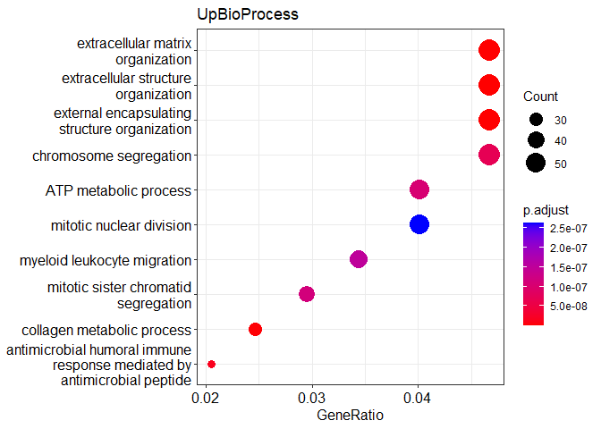

```r
dotplot(GO_BP_UP, title = "UpBioProcess")
```

### DOT PLOT FOR UP-REG Molecular Function (MF) LUNG

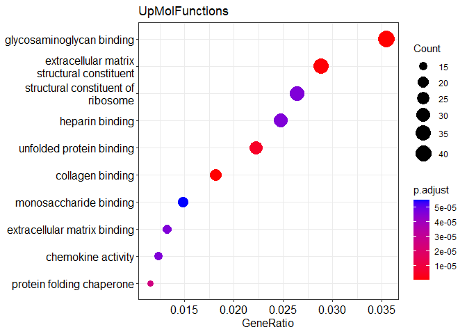

```r
dotplot(GO_MF_UP, title = "UpMolFunctions")
```

### DOT PLOT FOR UP-REG Biological Process (BP) COLON

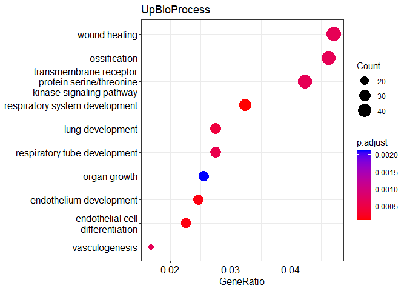

```r
dotplot(GO_BP_UP1, title = "UpBioProcess")
```

### DOT PLOT FOR UP-REG Molecular Function (MF) COLON

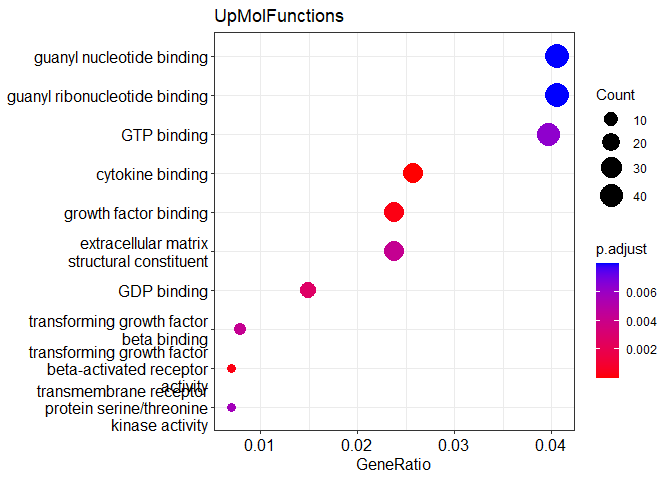

```r
dotplot(GO_MF_UP1, title = "UpMolFunctions")
```

# Gene Ontology (GO) Enrichment analysis

## DOWN-REGULATED

**LUNG** I perform the same passages for down-regulated genes:

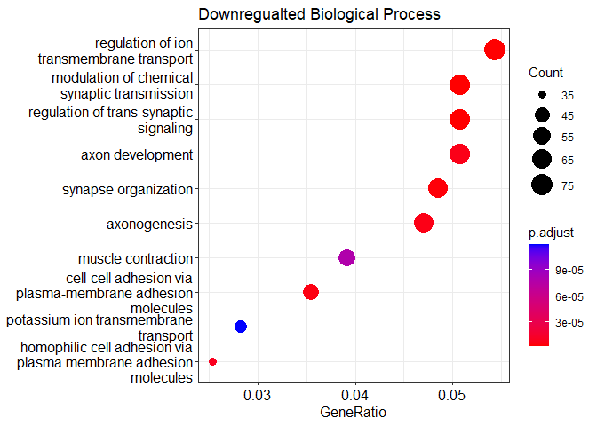

```r
downReg <- subset(resSig, log2FoldChange < -1)
downReg$symbol <- mapIds(org.Hs.eg.db,
                         keys=rownames(downReg),
                         column="SYMBOL",
                         keytype="ENSEMBL",
                         multiVals="first")

GO_BP_DOWN <- enrichGO(downReg$symbol, OrgDb = "org.Hs.eg.db",
                       keyType = "SYMBOL", ont = "BP")
GO_MF_DOWN <- enrichGO(downReg$symbol, OrgDb = "org.Hs.eg.db",
                       keyType = "SYMBOL", ont = "MF")
dotplot(GO_BP_DOWN, title = "Downregualted Biological Process")
```

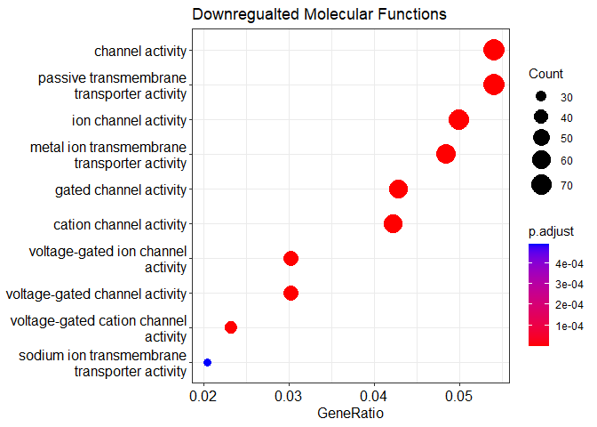

```r
dotplot(GO_MF_DOWN, title = "Downregualted Molecular Functions")
```

**COLON**

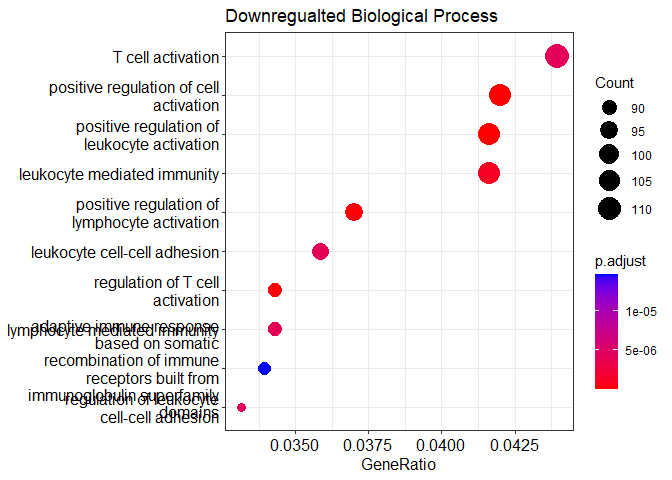

```r
downReg1 <- subset(resSig1, log2FoldChange < -1)
downReg1$symbol <- mapIds(org.Hs.eg.db,
                         keys=rownames(downReg1),
                         column="SYMBOL",
                         keytype="ENSEMBL",
                         multiVals="first")

GO_BP_DOWN1 <- enrichGO(downReg1$symbol, OrgDb = "org.Hs.eg.db",
                       keyType = "SYMBOL", ont = "BP")
GO_MF_DOWN1 <- enrichGO(downReg1$symbol, OrgDb = "org.Hs.eg.db",
                       keyType = "SYMBOL", ont = "MF")
dotplot(GO_BP_DOWN1, title = "Downregualted Biological Process")
```

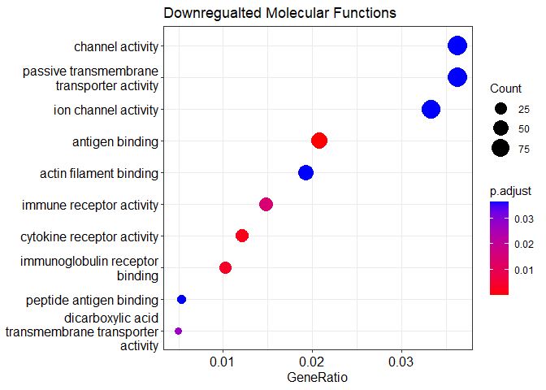

```r
dotplot(GO_MF_DOWN1, title = "Downregualted Molecular Functions")
```